# Soc722 - SR Chapter 3

Turgut Keskintürk

2022-09-23

Hello there! Let’s start with our exercises for McElreath’s *Statistical Rethinking*, Chapter 3.

# 1 Set-Up

```r
# load the relevant packages
library(tidyverse) # again, I silenced this chunk to exclude messages.
library(rethinking)
```

# 2 Responses to Questions

## 2.1 Easy Problems

I use McElreath’s code block (3.27) to have a specific set of samples first, per instructions. I change certain parts to tidyverse format. I am not sure if `dplyr` sampling is exactly the same to base `sample`, so for this particular example, I used the base version.

```r
# construct the data

d <- tibble(p_grid = seq(
  from = 0,
  to = 1,
  length.out = 1000
),
prior = rep(1, 1000)) %>%
  mutate(likelihood = dbinom(6, size = 9, prob = p_grid)) %>%
  mutate(posterior = likelihood * prior / sum(likelihood * prior))

# set seed

set.seed(100)

# draw some good old samples

samples <- tibble(samples = sample(
  d$p_grid,
  prob = d$posterior,
  size = 1e4,
  replace = TRUE
))
```

**3E1**. Posterior probability that lies below p = 0.2.

```r
samples %>%
  filter(samples < 0.2) %>%
  summarise(sum = n() / 1e4)
```

```
## # A tibble: 1 × 1
##      sum
##    <dbl>
## 1 0.0004
```

The answer is **0.0004**. *Very low!*

**3E2**. Posterior probability that lies above p = 0.8.

```r
samples %>%
  filter(samples > 0.8) %>%
  summarise(sum = n() / 1e4)
```

```
## # A tibble: 1 × 1
##     sum
##   <dbl>
## 1 0.112
```

The answer is **0.112**

**3E3**. Posterior probability that lies between p = 0.2 and p = 0.8.

```r
samples %>%
  filter(samples > 0.2 & samples < 0.8) %>%
  summarise(sum = n() / 1e4)
```

```
## # A tibble: 1 × 1
##     sum
##   <dbl>
## 1 0.888
```

Well, we would expect to see something that nearly (the exact points excluded though) sums to 1, so the answer is **0.888.** OK, we now turn to the questions that ask us to compute the opposite of what we had above.

**3E4**. 20% of the posterior probability lies below:

```r
samples %>%
  summarise(`20th percentile` = quantile(samples, p = .2))
```

```
## # A tibble: 1 × 1
##   `20th percentile`
##               <dbl>
## 1             0.519
```

We see that the answer is **0.519**.

**3E5**. 20% of the posterior probability lies above:

```r
samples %>%
  summarise(`80th percentile` = quantile(samples, p = .8))
```

```
## # A tibble: 1 × 1
##   `80th percentile`
##               <dbl>
## 1             0.756
```

We see that the answer is **0.756**.

**3E6**. The question asks of values of *p* that contain the narrowest interval equal to 66% of posterior probability.

```r
rethinking::HPDI(samples$samples, prob = 0.66)
```

```
##     |0.66     0.66|
## 0.5085085 0.7737738
```

**3E7**. The question asks of values of *p* that contain 66% of the posterior probability, assuming equality below and above the interval.

```r
rethinking::PI(samples$samples, prob = 0.66)
```

```
##       17%       83%
## 0.5025025 0.7697698
```

Nice tricks! We have completed the easy problems.

## 2.2 Medium Problems

Let’s clean up the environment before proceeding to the next set of questions (my motto: best environment is a clean environment).

```r
rm(list = ls())
```

The next set of questions wants us to assume that globe tossing data end up with 8 water in 15 tosses.

**3M1**. Let’s construct the posterior distribution using grid approximation.

```r
d <- tibble(p_grid = seq(
  from = 0,
  to = 1,
  length.out = 1000
),
prior = rep(1, 1000)) %>%
  mutate(likelihood = dbinom(8, size = 15, prob = p_grid)) %>%
  mutate(posterior = likelihood * prior / sum(likelihood * prior))
```

**3M2**. Nice, we have the posterior distribution with flat priors now. Let’s now draw 10,000 (=1e4) samples from this approximation. Then, we are asked to return the 90% HPDI for *p*.

```r
# sampling

set.seed(112358)

samples <-
  d %>%
  dplyr::slice_sample(n = 1e4, weight_by = posterior, replace = T)

# hpdi

rethinking::HPDI(samples$p_grid, prob = 0.9)
```

```
##      |0.9      0.9|
## 0.3303303 0.7157157
```

Nicely done!

**3M3**. We are going to construct a posterior predictive check for the data. In doing this, I will (a) simulate the distribution, (b) averaging over the posterior uncertainty in *p*. We are asked for Pr(8 Water in 15 Tosses).

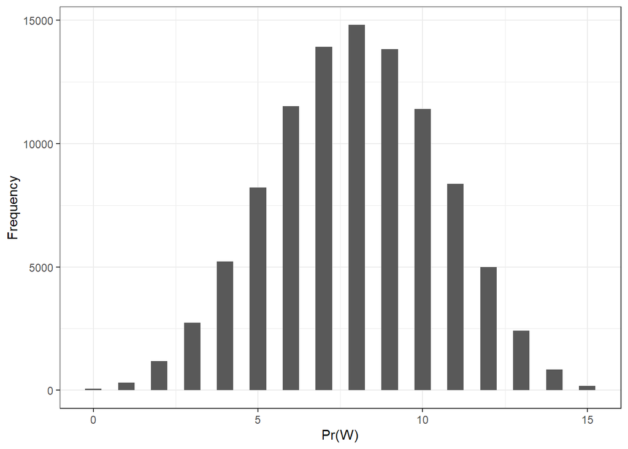

```r
# create a dummy data with 100,000 observations

set.seed(112358)

dummy <- tibble(draws = rbinom(1e5, size = 15, prob = samples$p_grid))

# plot

dummy %>%
  ggplot(aes(x = draws)) +
  geom_histogram(binwidth = 0.5) +
  theme_bw() +
  labs(x = "Pr(W)", y = "Frequency")
```

```r
# probability of observing 8 tosses

dummy %>%
  filter(draws == 8) %>%
  summarize(Prob = n() / 1e5)
```

```
## # A tibble: 1 × 1
##    Prob
##   <dbl>
## 1 0.148
```

We see that the probability of observing 8 tosses out of 15 is **0.148**.

**3M4**. Now, we are gonna look at the Pr(6 Water in 9 Tosses).

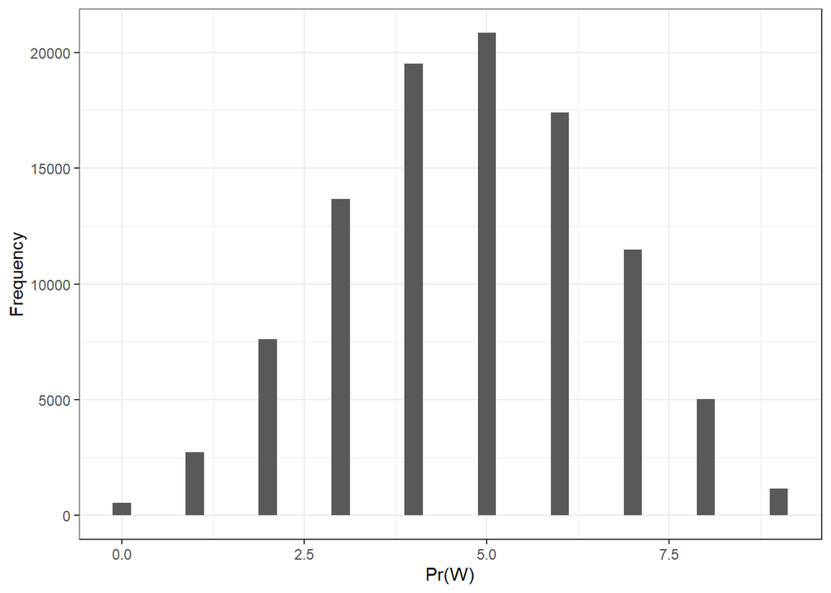

```r
# create a dummy data with 100,000 observations

set.seed(112358)

dummy <- tibble(draws = rbinom(1e5, size = 9, prob = samples$p_grid))

# plot

dummy %>%
  ggplot(aes(x = draws)) +
  geom_histogram(binwidth = 0.25) +
  theme_bw() +
  labs(x = "Pr(W)", y = "Frequency")
```

```r
# probability of observing 6 tosses

dummy %>%
  filter(draws == 6) %>%
  summarize(Prob = n() / 1e5)
```

```
## # A tibble: 1 × 1
##    Prob
##   <dbl>
## 1 0.174
```

Cool! The answer is **0.174**.

**3M5**. OK, we are now changing our priors. Exciting! If *p* < 0.5, we are gonna use 0, and constant otherwise. Everything is same.

```r
# clean-up again

rm(list = ls())

# new distribution

d <- tibble(
  p_grid = seq(
    from = 0,
    to = 1,
    length.out = 1000
  ),
  prior = ifelse(p_grid <= 0.5, 0, 1)
) %>%
  mutate(likelihood = dbinom(8, size = 15, prob = p_grid)) %>%
  mutate(posterior = likelihood * prior / sum(likelihood * prior))

# sampling

set.seed(112358)

samples <-
  d %>%
  dplyr::slice_sample(n = 1e4,
                      weight_by = posterior,
                      replace = T)
```

Nice. We updated everything. Let’s look at the HPDI, and the remaining plots.

```r
# hpdi

rethinking::HPDI(samples$p_grid, prob = 0.9)
```

```
##      |0.9      0.9|
## 0.5005005 0.7127127
```

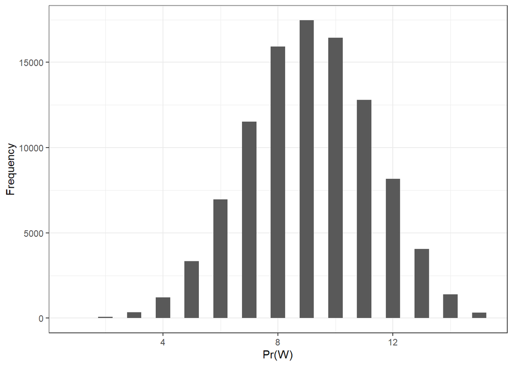

```r
# 8 out of 15 tosses

## create a dummy data with 100,000 observations

set.seed(112358)

dummy <- tibble(draws = rbinom(1e5, size = 15, prob = samples$p_grid))

## plot

dummy %>%
  ggplot(aes(x = draws)) +
  geom_histogram(binwidth = 0.5) +
  theme_bw() +
  labs(x = "Pr(W)", y = "Frequency")
```

```r
## probability of observing 8 tosses

dummy %>%
  filter(draws == 8) %>%
  summarize(Prob = n() / 1e5)
```

```
## # A tibble: 1 × 1
##    Prob
##   <dbl>
## 1 0.159
```

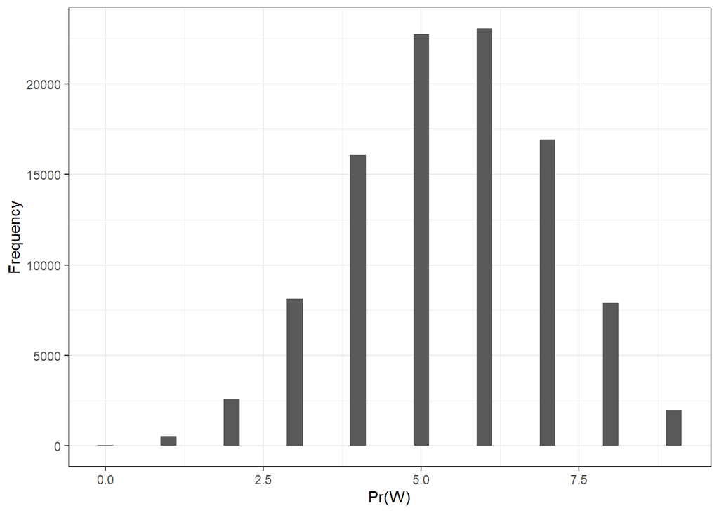

```r
# 6 out of 9 tosses

## create a dummy data with 100,000 observations

set.seed(112358)

dummy <- tibble(draws = rbinom(1e5, size = 9, prob = samples$p_grid))

## plot

dummy %>%
  ggplot(aes(x = draws)) +
  geom_histogram(binwidth = 0.25) +
  theme_bw() +
  labs(x = "Pr(W)", y = "Frequency")
```

```r
## probability of observing 6 tosses

dummy %>%
  filter(draws == 6) %>%
  summarize(Prob = n() / 1e5)
```

```
## # A tibble: 1 × 1
##    Prob
##   <dbl>
## 1 0.231
```

OK, we see that HPDI is pushed to the right. Similar observations can be made with regard to the probabilities (8 out of 15 is pushed to 0.148 to 0.159, and 6 out of 9 is pushed from 0.174 to 0.231).

**3M6**. It seems that I am gonna do some for loops. But not sure.

```r
# automate?

how_many_tosses <- matrix(nrow = 250, ncol = 2)
  loop_friend <- 1

for (i in seq(from = 1, to = 5000, by = 20)) {
  precise_rbinoms <- rbinom(1, size = i, prob = 0.7)
  precise_rbinoms <-
    tibble(p_grid = seq(from = 0, to = 1, length.out = 1000),
           prior = rep(1, 1000)) %>%
    mutate(likelihood = dbinom(precise_rbinoms, size = i, prob = p_grid)) %>%
    mutate(posterior = likelihood * prior / sum(likelihood * prior))
  precise_samples <- precise_rbinoms %>%
    slice_sample(n = 10000, weight_by = posterior, replace = TRUE)
  intervals <- rethinking::PI(precise_samples$p_grid, prob = .99)
  how_many_tosses[[loop_friend, 1]] <- i
  how_many_tosses[[loop_friend, 2]] <- intervals[[2]] - intervals[[1]]
  loop_friend <- loop_friend + 1
}

# making it easy

how_many_tosses <- as.data.frame(how_many_tosses)
```

Aaah, no. This makes us approximate, but for a precise answer, no. I give up.

## 2.3 Hard Problems

It is now time for the hard problems. Scary. But fun maybe? Let’s see.

We are going to load the data first.

```r
rm(list = ls())
data(homeworkch3)

# maybe a tibble data frame would work later on?

df <- tibble(
  birth1 = birth1,
  birth2 = birth2,
  b = birth1 + birth2,
  g = 2 - b
)
```

**3H1**. We are going to use grid approximation to compute the posterior distribution of a birth being boy.

```r
# construct the posterior distribution

d <- tibble(p_grid = seq(
  from = 0,
  to = 1,
  length.out = 100
),
prior = rep(1, 100)) %>%
  mutate(likelihood = dbinom(sum(df$b), size = 200, prob = p_grid)) %>%
  mutate(posterior = likelihood * prior / sum(likelihood * prior))

# which parameter value maximizes the posterior probability?

d %>%
  arrange(desc(posterior)) %>%
  slice(1) %>%
  print()
```

```
## # A tibble: 1 × 4
##   p_grid prior likelihood posterior
##    <dbl> <dbl>      <dbl>     <dbl>
## 1  0.556     1     0.0567     0.115
```

It seems that the parameter value **0.556** maximizes the posterior probability.

**3H2**. We are now going to sample 10,000 random parameters from the posterior distributions above.

```r
# sampling

set.seed(112358)

samples <-
  d %>%
  dplyr::slice_sample(n = 1e4, weight_by = posterior, replace = T)

# highest posterior density intervals

rethinking::HPDI(samples$p_grid, prob = 0.50)
```

```
##      |0.5      0.5|
## 0.5454545 0.5858586
```

```r
rethinking::HPDI(samples$p_grid, prob = 0.89)
```

```
##     |0.89     0.89|
## 0.5050505 0.6060606
```

```r
rethinking::HPDI(samples$p_grid, prob = 0.97)
```

```
##     |0.97     0.97|
## 0.4848485 0.6262626
```

Cool!

**3H3**. Let’s go with simulation. King McElreath proposes the `dens` command, so no tidyverse this time, Nico!

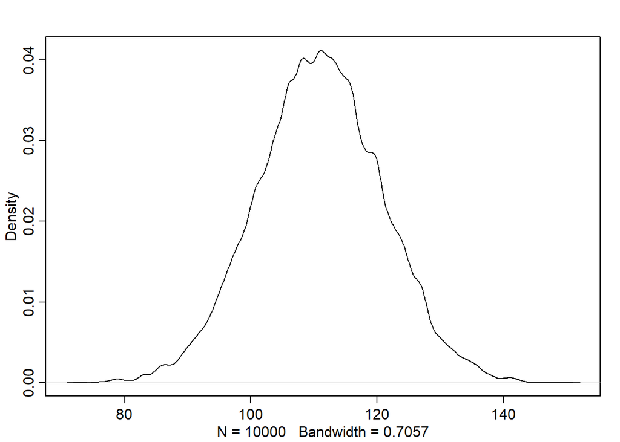

```r
# draws

set.seed(112358)
dummy <- tibble(draws = rbinom(1e4, size = 200, prob = samples$p_grid))

# plot

rethinking::dens(dummy$draws)
```

Yes, it seems that the data shows that the actual observation is a central outcome.

**3H4**. Now, we are going to simulate only 100 observations, and compare this with 10,000 dummy observations.

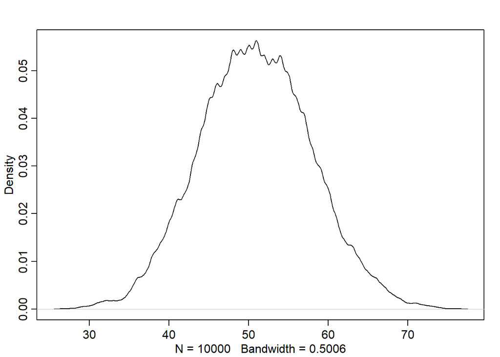

```r
# recalibration

d <- tibble(p_grid = seq(
  from = 0,
  to = 1,
  length.out = 100
),
prior = rep(1, 100)) %>%
  mutate(likelihood = dbinom(sum(df$birth1), size = 100, prob = p_grid)) %>%
  mutate(posterior = likelihood * prior / sum(likelihood * prior))

# new sampling for the first borns

samples <-
  d %>%
  dplyr::slice_sample(n = 1e4, weight_by = posterior, replace = T)

# new draws

set.seed(112358)
dummy_new <- tibble(draws = rbinom(1e4, size = 100, prob = samples$p_grid))

# plot

rethinking::dens(dummy_new$draws)
```

The actual number of boys in first-borns is `sum(birth1)` = **51**, which is pretty close, once more, to the modal value in this plot.

**3H5**. OK, this is a bit complicated. I think we first need to know the number of girls among those who are first-born. This is easy. We can basically look it up as `sum(birth1==0)`, which equals to 49. Now, we are going to simulate 10,000 births.

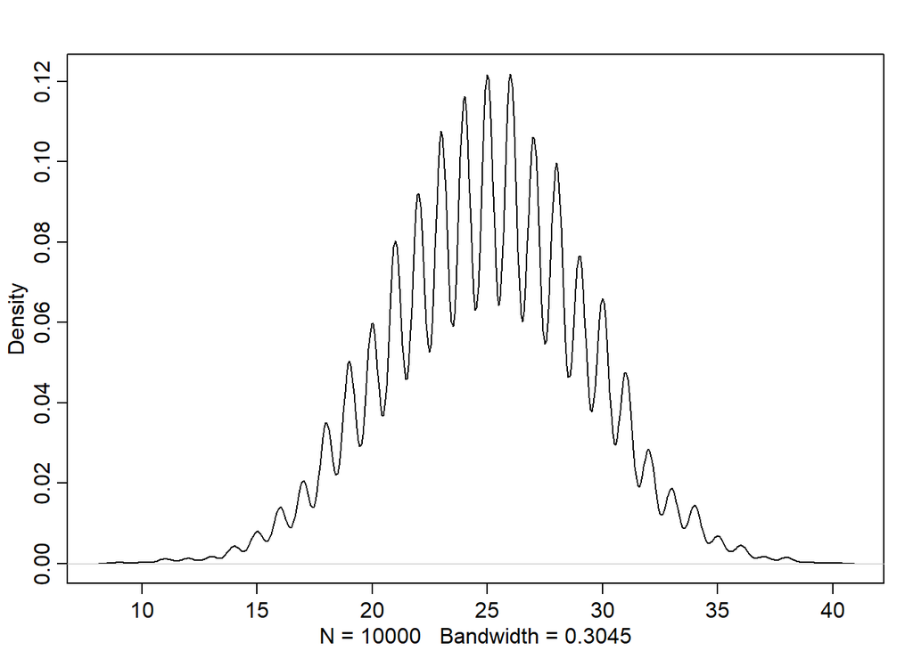

```r
girls_simulation <- tibble(draws = rbinom(1e4, size = 49, prob = samples$p_grid))

# same plot for McElreath

rethinking::dens(girls_simulation$draws)
```

OK, now, as you can see, the modal response turns to 25. What about the number of boys following the first-born girls. Let’s learn that.

```r
df %>%
  filter(birth1 == 0) %>%
  summarize(sumboys = sum(birth2))
```

```
## # A tibble: 1 × 1
##   sumboys
##     <dbl>
## 1      39
```

Huh, we see 39 boys here, compared to 25ish numbers, which suggests that the processes are not independent; namely, the first birth and the second birth has some sort of a dependence relationship in terms of biological sex!

Thank you!